# Supplement 2

Descriptive statistics of baseline variables: SN:yes vs SN:no

Peter Kamerman and Prinisha Pillay

17 November 2018

This script describes variables collected at baseline (visit day: 0, visit_number: 1) conditioned on sensory neuropathy (SN) status (i.e., whether SN developed at any point during the follow-up period).

For descriptive statistics of baseline variables for the whole cohort, see: `suppl-01-descriptive-whole-cohort.[Rmd/html/md/pdf]`

The following data columns were not analysed:

- `pain` and `pain score`: related to SN only, therefore not relevant at baseline when everyone was free from SN.
- `*_record`: inconsistent patient records.
- `hba1c_percent/diabetic_hba1c` and `vitaminB12_pmol.l/vitaminB12_deficiency`: Zero and one participant had diabetes mellitus or vitamin B12 deficiency, respectively, so these data were not analysed.
- `ID`, `visit_day`, `hivsn_present`, `visit_months`: provide sorting and grouping information only.

# Define bootstrap functions

Functions calculate the 95% confidence interval of the mean/median difference between SN:yes and SN:no, or the 95% confidence interval for the odds ratio between the two groups.

```r
# Difference between means
## d = dataframe object
## i = boot index
## data_column = data column (character vector of length 1)
## grouping_column = grouping variable column (character vector of length 1)
boot_deltaMean <- function(d, i, data_column = NULL, grouping_column = NULL){
    # Sample
    df <- d[i, c(data_column, grouping_column)]
    # Rename columns
    colnames(df) <- c('x', 'y')
    # Calculate means
    df <- df %>%
        filter(!is.na(x)) %>%
        group_by(y) %>%
        summarise(mean = mean(x)) %>%
        ungroup()
    # Calculate difference in means
    df$mean[1] - df$mean[2]
}

# Difference between medians
## d = dataframe object
## i = boot index
## data_column = data column (character vector of length 1)
## grouping_column = grouping variable column (character vector of length 1)
boot_deltaMedian <- function(d, i, data_column = NULL, grouping_column = NULL){
    # Sample
    df <- d[i, c(data_column, grouping_column)]
    # Rename columns
    colnames(df) <- c('x', 'y')
    # Calculate means
    df <- df %>%
        filter(!is.na(x)) %>%
        group_by(y) %>%
        summarise(median = median(x)) %>%
        ungroup()
    # Calculate difference in means
    df$median[1] - df$median[2]
}

# Odds ratio
## d = dataframe object
## i = boot index
## data_column = data column (character vector of length 1)
## grouping_column = grouping variable column (character vector of length 1)
boot_OR <- function(d, i, data_column = NULL, grouping_column = NULL){
    # Sample
    df <- d[i, c(data_column, grouping_column)]
    # Rename columns
    colnames(df) <- c('x', 'y')
    # xtabulate
    x_tab <- xtabs(~ x + y,
                  data = df)
    # Calculate odds ratio
    fisher.test(x_tab)$estimate
}
```

# Import data

```r
data <- read_rds('data-clean/clean_data.rds') %>%
    # Remove columns that won't be analysed
    select(-starts_with('pain'), -ends_with('_record'),
           -starts_with('vitaminB12'), -visit_months,
           -hba1c_percent, -vitaminB12_pmol.l, -diabetic_hba1c)
```

# Process data

Add a column indicating whether a participant developed SN at any time during the follow-up period, and then filter the dataframe to only contain rows of data from visit 1.

```r
# Identify andf extract information on SN development (at anytime)
# by looking at the presence of SN at the final visit
data_sn <- data %>%
    select(ID, visit_number, hivsn_present) %>%
    group_by(ID) %>%
    mutate(max_visit = max(visit_number)) %>%
    filter(visit_number == max_visit) %>%
    select(ID, hivsn_present) %>%
    rename(sn_present = hivsn_present)

# Join data_sn to data
data %<>%
    left_join(data_sn)

# Restrict data to the baseline visit (visit 1)
data %<>%
    filter(visit_number == 1)

# Order sn_present factor to improved plotting order
data %<>%
    mutate(sn_present = factor(sn_present,
                               levels = c('yes', 'no'),
                               ordered = TRUE))
```

# Inspect data

```r
# Dimensions
dim(data)
```

```
## [1] 83 17
```

```r
# Column names
names(data)
```

```
##  [1] "ID"                     "visit_number"
##  [3] "visit_day"              "age_years"
##  [5] "mass_kg"                "height_m"
##  [7] "sex"                    "hivsn_present"
##  [9] "CD4_cell.ul"            "viral_load_copies.ml"
## [11] "consumes_alcohol"       "alcohol_units.week"
## [13] "TB_current"             "pyridoxine_prophylaxis"
## [15] "rifafour_treatment"     "ARV_regimen"
## [17] "sn_present"
```

```r
# Head and tail
head(data)
```

```
## # A tibble: 6 x 17
##   ID    visit_number visit_day age_years mass_kg height_m sex
##   <chr>        <int>     <int>     <dbl>   <dbl>    <dbl> <fct>
## 1 001              1         0        59    41.4     1.56 F
## 2 002              1         0        23    70.2     1.56 F
## 3 003              1         0        27    75       1.64 M
## 4 004              1         0        26    68.8     1.74 M
## 5 005              1         0        37   107       1.6  F
## 6 006              1         0        34    85.5     1.53 F
## # ... with 10 more variables: hivsn_present <fct>, CD4_cell.ul <dbl>,
## #   viral_load_copies.ml <dbl>, consumes_alcohol <fct>,
## #   alcohol_units.week <int>, TB_current <fct>,
## #   pyridoxine_prophylaxis <fct>, rifafour_treatment <fct>,
## #   ARV_regimen <fct>, sn_present <ord>
```

```r
tail(data)
```

```
## # A tibble: 6 x 17
##   ID    visit_number visit_day age_years mass_kg height_m sex
##   <chr>        <int>     <int>     <dbl>   <dbl>    <dbl> <fct>
## 1 078              1         0        29    54       1.53 F
## 2 079              1         0        44    58.8     1.52 F
## 3 080              1         0        50    53.2     1.51 F
## 4 081              1         0        43    49.5     1.62 F
## 5 082              1         0        40    82.8     1.62 F
## 6 083              1         0        46    73.3     1.66 F
## # ... with 10 more variables: hivsn_present <fct>, CD4_cell.ul <dbl>,
## #   viral_load_copies.ml <dbl>, consumes_alcohol <fct>,
## #   alcohol_units.week <int>, TB_current <fct>,
## #   pyridoxine_prophylaxis <fct>, rifafour_treatment <fct>,
## #   ARV_regimen <fct>, sn_present <ord>
```

```r
# Data structure
glimpse(data)
```

```
## Observations: 83
## Variables: 17
## $ ID                     <chr> "001", "002", "003", "004", "005", "006...
## $ visit_number           <int> 1, 1, 1, 1, 1, 1, 1, 1, 1, 1, 1, 1, 1, ...
## $ visit_day              <int> 0, 0, 0, 0, 0, 0, 0, 0, 0, 0, 0, 0, 0, ...
## $ age_years              <dbl> 59, 23, 27, 26, 37, 34, 44, 34, 32, 29,...
## $ mass_kg                <dbl> 41.4, 70.2, 75.0, 68.8, 107.0, 85.5, 12...
## $ height_m               <dbl> 1.56, 1.56, 1.64, 1.74, 1.60, 1.53, 1.6...
## $ sex                    <fct> F, F, M, M, F, F, F, F, F, M, M, M, M, ...
## $ hivsn_present          <fct> no, no, no, no, no, no, no, no, no, no,...
## $ CD4_cell.ul            <dbl> 35, 285, 28, 270, 310, 247, 439, 311, 1...
## $ viral_load_copies.ml   <dbl> 6.103804, 5.041393, 5.181844, 2.484300,...
## $ consumes_alcohol       <fct> no, no, no, no, yes, no, no, no, no, no...
## $ alcohol_units.week     <int> 0, 0, 0, 0, 15, 0, 0, 0, 0, 0, 0, 6, 9,...
## $ TB_current             <fct> no, no, yes, no, no, no, no, no, no, no...
## $ pyridoxine_prophylaxis <fct> no, no, yes, no, no, no, no, no, no, no...
## $ rifafour_treatment     <fct> no, no, yes, no, no, no, no, no, no, no...
## $ ARV_regimen            <fct> TDF_FTC_EFV, TDF_FTC_EFV, TDF_FTC_EFV, ...
## $ sn_present             <ord> no, no, no, no, no, yes, yes, no, no, n...
```

# Analyses

## Age

```r
# Tabular summary
data %>%
    select(age_years, sn_present) %>%
    group_by(sn_present) %>%
    skim()
```

```
## Skim summary statistics
##  n obs: 83
##  n variables: 2
##  group variables: sn_present
##
## ── Variable type:numeric ───────────────────────────────────────────────────────────────
##  sn_present  variable missing complete  n  mean   sd p0  p25  p50   p75
##         yes age_years       0       20 20 41.8  8.47 26 36.5 40.5 46.75
##          no age_years       0       63 63 37.68 9.11 21 31   37   43.5
##  p100     hist
##    59 ▂▅▅▇▅▂▃▃
##    59 ▃▅▆▅▇▂▁▂
```

```r
# 95% bootstrap confidence interval of the mean age by SN status
## Method = BCa, Resamples = 10000
set.seed(1234)
groupwiseMean(age_years ~ sn_present,
              data = data,
              R = 10000,
              traditional = FALSE,
              boot = TRUE,
              bca = TRUE)[c(1:3, 5, 6, 7)]
```

```
##   sn_present  n Mean Conf.level Bca.lower Bca.upper
## 1        yes 20 41.8       0.95      38.3      45.4
## 2         no 63 37.7       0.95      35.5      40.0
```

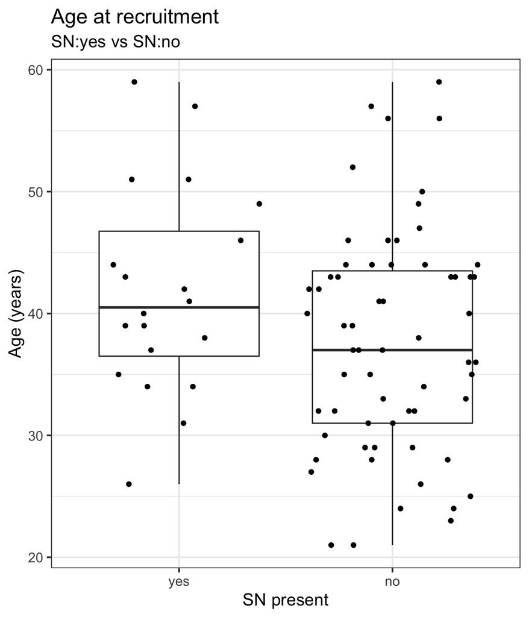

```r
# Plot
data %>%
    ggplot(data = .) +
    aes(y = age_years,
        x = sn_present) +
    geom_boxplot() +
    geom_jitter(height = 0) +
    labs(title = 'Age at recruitment',
         subtitle = 'SN:yes vs SN:no',
         y = 'Age (years)',
         x = 'SN present')
```

```r
# Bootstrap 95% CI for the difference in mean age
## Resample: 10000
set.seed(1234)
boot_age <- boot.ci(boot(data = data,
                         statistic = boot_deltaMean,
                         data_column = 'age_years',
                         grouping_column = 'sn_present',
                         R = 10000,
                         stype = 'i'),
                    type = 'bca') %>%
    data_frame(n = nrow(filter(data, !is.na(age_years))),
               Mean.difference = round(.$t0, 3),
               Conf.level = 0.95,
               Bca.lower = round(.$bca[[4]], 3),
               Bca.upper = round(.$bca[[5]], 3),
               Includes.zero = ifelse(Bca.lower <= 0 & Bca.upper >= 0,
                                      yes = 'yes',
                                      no = 'no')) %>%
    .[1, -1] %>%
    as.data.frame(); boot_age
```

```
##    n Mean.difference Conf.level Bca.lower Bca.upper Includes.zero
## 1 83           4.117       0.95    -0.133     8.585           yes
```

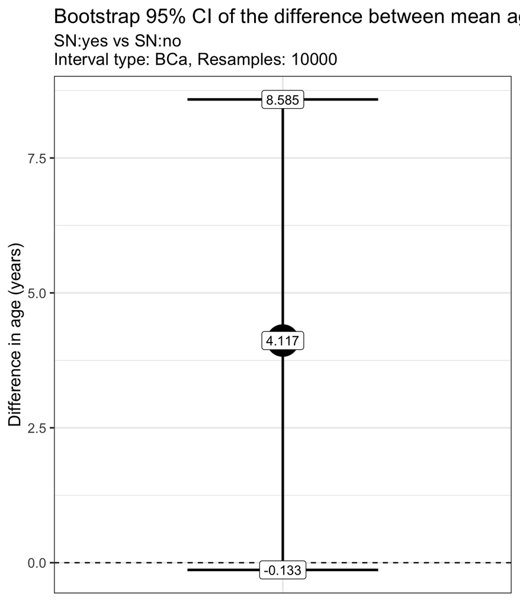

```r
ggplot(data = boot_age) +
    geom_hline(yintercept = 0,
               linetype = 2) +
    geom_point(aes(x = 'x',
                   y = Mean.difference),
               size = 12) +
    geom_errorbar(aes(x = 'x',
                      ymin = Bca.lower,
                      ymax = Bca.upper),
                  width = 0.5,
                  size = 1) +
    geom_label(aes(x = 'x',
                   y = Bca.lower,
                   label = Bca.lower)) +
    geom_label(aes(x = 'x',
                   y = Mean.difference,
                   label = Mean.difference)) +
    geom_label(aes(x = 'x',
                   y = Bca.upper,
                   label = Bca.upper)) +
    labs(title = 'Bootstrap 95% CI of the difference between mean age',
         subtitle = "SN:yes vs SN:no\nInterval type: BCa, Resamples: 10000",
         y = 'Difference in age (years)') +
    theme(axis.ticks.x = element_blank(),
          axis.text.x = element_blank(),
          axis.title.x = element_blank())
```

## Body mass

```r
# Tabular summary
data %>%
    select(mass_kg, sn_present) %>%
    group_by(sn_present) %>%
    skim()
```

```
## Skim summary statistics
##  n obs: 83
##  n variables: 2
##  group variables: sn_present
##
## ── Variable type:numeric ───────────────────────────────────────────────────────────────
##  sn_present variable missing complete  n  mean    sd   p0   p25   p50
##         yes  mass_kg       0       20 20 72.97 18.05 47.6 59.48 69.45
##          no  mass_kg       0       63 63 63.93 14.75 41.4 52.8  63
##    p75  p100     hist
##  84.15 121.4 ▇▅▆▅▅▂▁▂
##  73.4  107   ▇▇▆▇▅▃▁▁
```

```r
# 95% bootstrap confidence interval of the mean body mass by SN status
## Method = BCa, Resamples = 10000
set.seed(1234)
groupwiseMean(mass_kg ~ sn_present,
              data = data,
              R = 10000,
              traditional = FALSE,
              boot = TRUE,
              bca = TRUE)[c(1:3, 5, 6, 7)]
```

```
##   sn_present  n Mean Conf.level Bca.lower Bca.upper
## 1        yes 20 73.0       0.95      66.3      81.9
## 2         no 63 63.9       0.95      60.5      67.7
```

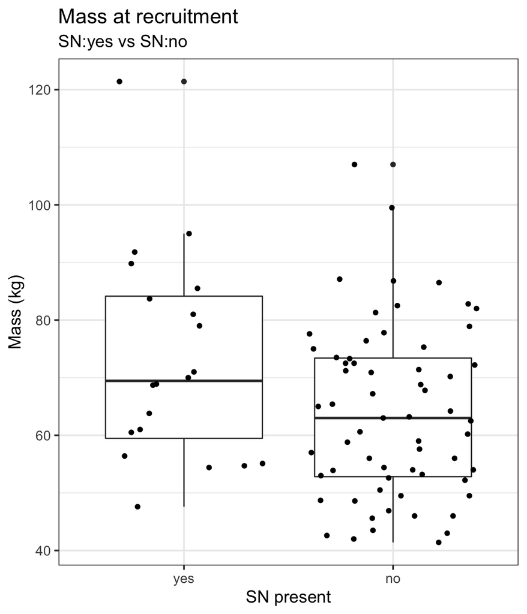

```r
# Plot
data %>%
    ggplot(data = .) +
    aes(y = mass_kg,
        x = sn_present) +
    geom_boxplot() +
    geom_jitter(height = 0) +
    labs(title = 'Mass at recruitment',
         subtitle = "SN:yes vs SN:no",
         y = 'Mass (kg)',
         x = 'SN present')
```

```r
# Bootstrap 95% CI for the difference in mean mass
## Resample: 10000
set.seed(1234)
boot_mass <- boot.ci(boot(data = data,
                          statistic = boot_deltaMean,
                          data_column = 'mass_kg',
                          grouping_column = 'sn_present',
                          R = 10000,
                          stype = 'i'),
                     type = 'bca') %>%
    data_frame(n = nrow(filter(data, !is.na(mass_kg))),
               Mean.difference = round(.$t0, 3),
               Conf.level = 0.95,
               Bca.lower = round(.$bca[[4]], 3),
               Bca.upper = round(.$bca[[5]], 3),
               Includes.zero = ifelse(Bca.lower <= 0 & Bca.upper >= 0,
                                      yes = 'yes',
                                      no = 'no')) %>%
    .[1, -1] %>%
    as.data.frame(); boot_mass
```

```
##    n Mean.difference Conf.level Bca.lower Bca.upper Includes.zero
## 1 83           9.035       0.95     1.122    18.457            no
```

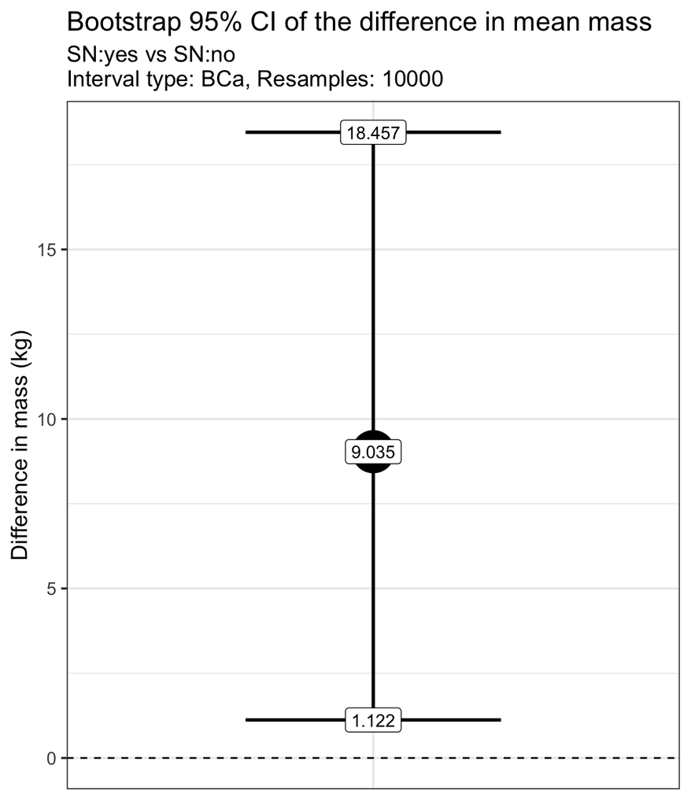

```r
ggplot(data = boot_mass) +
    geom_hline(yintercept = 0,
               linetype = 2) +
    geom_point(aes(x = 'x',
                   y = Mean.difference),
               size = 12) +
    geom_errorbar(aes(x = 'x',
                      ymin = Bca.lower,
                      ymax = Bca.upper),
                  width = 0.5,
                  size = 1) +
    geom_label(aes(x = 'x',
                   y = Bca.lower,
                   label = Bca.lower)) +
    geom_label(aes(x = 'x',
                   y = Mean.difference,
                   label = Mean.difference)) +
    geom_label(aes(x = 'x',
                   y = Bca.upper,
                   label = Bca.upper)) +
    labs(title = 'Bootstrap 95% CI of the difference in mean mass',
         subtitle = "SN:yes vs SN:no\nInterval type: BCa, Resamples: 10000",
         y = 'Difference in mass (kg)') +
    theme(axis.ticks.x = element_blank(),
          axis.text.x = element_blank(),
          axis.title.x = element_blank())
```

## Height

Expect height to show sex difference, so analyse separately for males and females.

```r
# Tabular summary
data %>%
    select(height_m, sex, sn_present) %>%
    group_by(sn_present, sex) %>%
    skim()
```

```
## Skim summary statistics
##  n obs: 83
##  n variables: 3
##  group variables: sn_present, sex
##
## ── Variable type:numeric ───────────────────────────────────────────────────────────────
##  sn_present sex variable missing complete  n mean    sd   p0  p25  p50
##         yes   F height_m       0        8  8 1.64 0.087 1.53 1.58 1.66
##         yes   M height_m       0       12 12 1.72 0.045 1.65 1.69 1.73
##          no   F height_m       0       38 38 1.57 0.061 1.46 1.52 1.56
##          no   M height_m       0       25 25 1.69 0.044 1.63 1.64 1.69
##   p75 p100     hist
##  1.7  1.76 ▇▁▃▃▁▇▃▃
##  1.75 1.79 ▇▃▃▇▃▇▇▃
##  1.62 1.68 ▂▇▇▇▃▇▅▅
##  1.72 1.77 ▇▁▁▇▃▃▃▂
```

```r
# 95% bootstrap confidence interval of the mean height by SN status
## Method = BCa, Resamples = 10000
set.seed(1234)
groupwiseMean(height_m ~ sn_present + sex,
              data = data,
              R = 10000,
              traditional = FALSE,
              boot = TRUE,
              bca = TRUE)[c(1:3, 5, 6:8)]
```

```
##   sn_present sex  n Boot.mean Conf.level Bca.lower Bca.upper
## 1        yes   F  8      1.64       0.95      1.58      1.70
## 2        yes   M 12      1.72       0.95      1.69      1.74
## 3         no   F 38      1.57       0.95      1.55      1.58
## 4         no   M 25      1.69       0.95      1.67      1.71
```

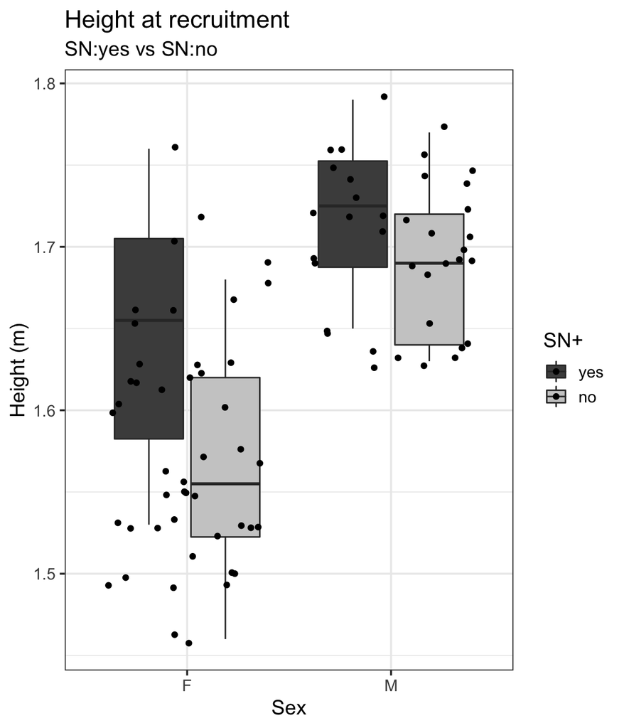

```r
# Plots
data %>%
    ggplot(data = .) +
    aes(y = height_m,
        x = sex,
        fill = sn_present) +
    geom_boxplot() +
    geom_jitter() +
    scale_fill_manual(name = 'SN+',
                      values = c('#4C4C4C', '#CCCCCC')) +
    labs(title = 'Height at recruitment',
         subtitle = "SN:yes vs SN:no",
         y = 'Height (m)',
         x = 'Sex')
```

```r
# MALES ONLY
## Bootstrap 95% CI for the difference in mean height
### Resample: 10000
set.seed(1234)
boot_hm <- boot.ci(boot(data = data[data$sex == 'M', ],
                        statistic = boot_deltaMean,
                        data_column = 'height_m',
                        grouping_column = 'sn_present',
                        R = 10000,
                        stype = 'i'),
                   type = 'bca') %>%
    data_frame(n = nrow(filter(data, !is.na(height_m) & sex == 'M')),
               Mean.difference = round(.$t0, 3),
               Conf.level = 0.95,
               Bca.lower = round(.$bca[[4]], 3),
               Bca.upper = round(.$bca[[5]], 3),
               Includes.zero = ifelse(Bca.lower <= 0 & Bca.upper >= 0,
                                      yes = 'yes',
                                      no = 'no')) %>%
    .[1, -1] %>%
    as.data.frame(); boot_hm
```

```
##    n Mean.difference Conf.level Bca.lower Bca.upper Includes.zero
## 1 37           0.028       0.95    -0.003     0.058           yes
```

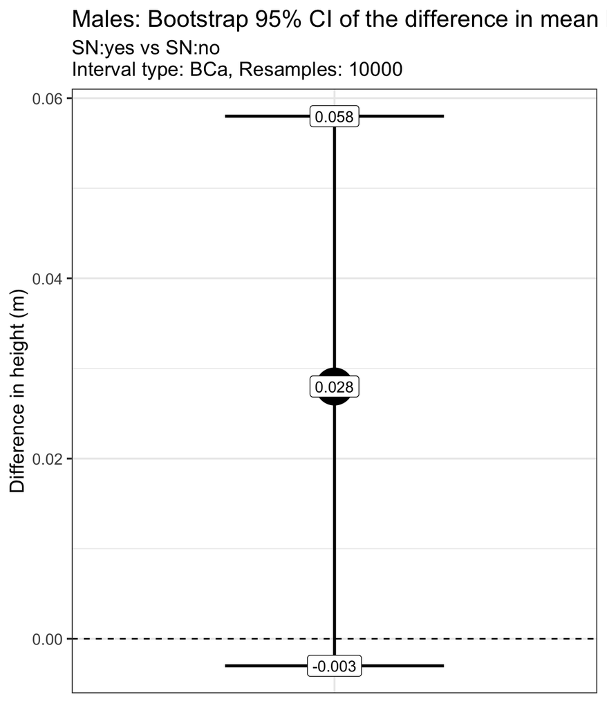

```r
ggplot(data = boot_hm) +
    geom_hline(yintercept = 0,
               linetype = 2) +
    geom_point(aes(x = 'x',
                   y = Mean.difference),
               size = 12) +
    geom_errorbar(aes(x = 'x',
                      ymin = Bca.lower,
                      ymax = Bca.upper),
                  width = 0.5,
                  size = 1) +
    geom_label(aes(x = 'x',
                   y = Bca.lower,
                   label = Bca.lower)) +
    geom_label(aes(x = 'x',
                   y = Mean.difference,
                   label = Mean.difference)) +
    geom_label(aes(x = 'x',
                   y = Bca.upper,
                   label = Bca.upper)) +
    labs(title = 'Males: Bootstrap 95% CI of the difference in mean height',
         subtitle = "SN:yes vs SN:no\nInterval type: BCa, Resamples: 10000",
         y = 'Difference in height (m)') +
    theme(axis.ticks.x = element_blank(),
          axis.text.x = element_blank(),
          axis.title.x = element_blank())
```

```r
# FEMALES ONLY
## Bootstrap 95% CI for the difference in mean height
### Resample: 9000 (10000 gives a wierd error)
set.seed(1234)
boot_hf <- boot.ci(boot(data = data[data$sex == 'F', ],
                        statistic = boot_deltaMean,
                        data_column = 'height_m',
                        grouping_column = 'sn_present',
                        R = 10000,
                        stype = 'i'),
                   type = 'bca') %>%
    data_frame(n = nrow(filter(data, !is.na(height_m) & sex == 'F')),
               Mean.difference = round(.$t0, 3),
               Conf.level = 0.95,
               Bca.lower = round(.$bca[[4]], 3),
               Bca.upper = round(.$bca[[5]], 3),
               Includes.zero = ifelse(Bca.lower <= 0 & Bca.upper >= 0,
                                      yes = 'yes',
                                      no = 'no')) %>%
    .[1, -1] %>%
    as.data.frame(); boot_hf
```

```
##    n Mean.difference Conf.level Bca.lower Bca.upper Includes.zero
## 1 46           0.078       0.95     0.012      0.14            no
```

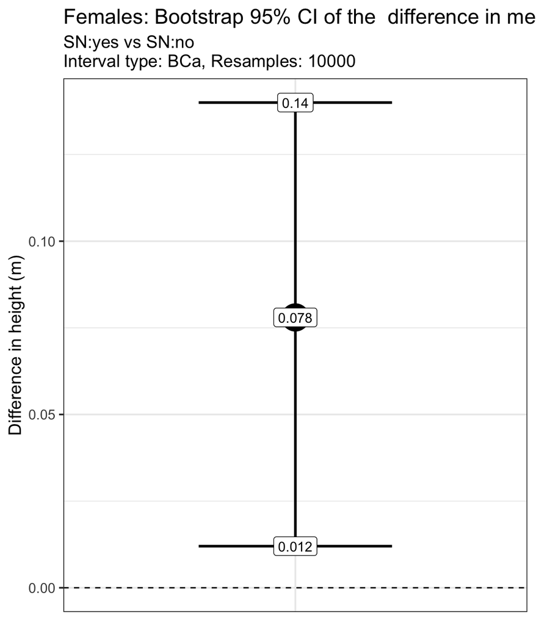

```r
ggplot(data = boot_hf) +
     geom_hline(yintercept = 0,
               linetype = 2) +
    geom_point(aes(x = 'x',
                   y = Mean.difference),
               size = 10) +
    geom_errorbar(aes(x = 'x',
                      ymin = Bca.lower,
                      ymax = Bca.upper),
                  width = 0.5,
                  size = 1) +
    geom_label(aes(x = 'x',
                   y = Bca.lower,
                   label = Bca.lower)) +
    geom_label(aes(x = 'x',
                   y = Mean.difference,
                   label = Mean.difference)) +
    geom_label(aes(x = 'x',
                   y = Bca.upper,
                   label = Bca.upper)) +
    labs(title = 'Females: Bootstrap 95% CI of the  difference in mean height',
         subtitle = "SN:yes vs SN:no\nInterval type: BCa, Resamples: 10000",
         y = 'Difference in height (m)') +
    theme(axis.ticks.x = element_blank(),
          axis.text.x = element_blank(),
          axis.title.x = element_blank())
```

## Sex

```r
# Tabular summary
data %>%
    select(sex, sn_present) %>%
    group_by(sn_present) %>%
    skim()
```

```
## Skim summary statistics
##  n obs: 83
##  n variables: 2
##  group variables: sn_present
##
## ── Variable type:factor ────────────────────────────────────────────────────────────────
##  sn_present variable missing complete  n n_unique          top_counts
##         yes      sex       0       20 20        2  M: 12, F: 8, NA: 0
##          no      sex       0       63 63        2 F: 38, M: 25, NA: 0
##  ordered
##    FALSE
##    FALSE
```

```r
# 95% bootstrap confidence interval of the proportion of females by SN status
## Method = BCa, Resamples = 10000
### SN:yes
set.seed(1234)
sn_yes <- boot.ci(boot(data = data[data$sn_present == 'yes', ],
                       statistic = function(d, i){
                           mean(d[i, 'sex'] == 'F')},
                       R = 10000,
                       stype = 'i'),
                  type = 'bca') %>%
    data_frame(sn_present = 'yes',
               n = nrow(filter(data, !is.na(sex) &
                                   sn_present == 'yes')),
               Proportion = round(.$t0, 3),
               Conf.level = 0.95,
               Bca.lower = round(.$bca[[4]], 3),
               Bca.upper = round(.$bca[[5]], 3)) %>%
    .[1, -1] %>%
    as.data.frame()

### SN:no
set.seed(1234)
sn_no <- boot.ci(boot(data = data[data$sn_present == 'no', ],
                      statistic = function(d, i){
                          mean(d[i, 'sex'] == 'F')},
                      R = 10000,
                      stype = 'i'),
                 type = 'bca') %>%
    data_frame(sn_present = 'no',
               n = nrow(filter(data, !is.na(sex) &
                                   sn_present == 'yes')),
               Proportion = round(.$t0, 3),
               Conf.level = 0.95,
               Bca.lower = round(.$bca[[4]], 3),
               Bca.upper = round(.$bca[[5]], 3)) %>%
    .[1, -1] %>%
    as.data.frame()

### Put sn and sn_no together and print
sn_yes %>%
    bind_rows(sn_no)
```

```
##   sn_present  n Proportion Conf.level Bca.lower Bca.upper
## 1        yes 20      0.400       0.95      0.15     0.550
## 2         no 20      0.603       0.95      0.46     0.698
```

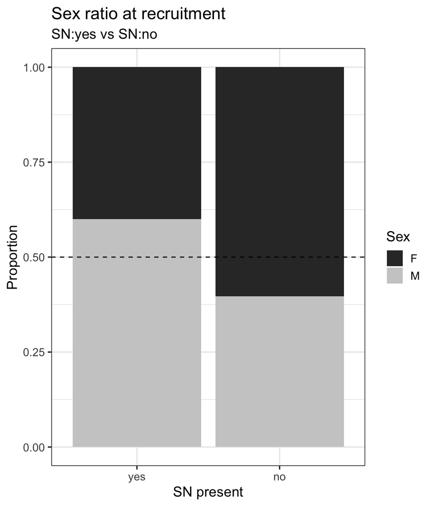

```r
# Plot
data %>%
    ggplot(data = .) +
    aes(x = sn_present,
        fill = sex) +
    geom_bar(position = 'fill') +
    geom_hline(yintercept = 0.5,
               linetype = 2) +
    labs(title = 'Sex ratio at recruitment',
         subtitle = "SN:yes vs SN:no",
         y = 'Proportion',
         x = 'SN present') +
    scale_fill_grey(name = 'Sex')
```

```r
# Bootstrap 95% CI for the odds ratio of SN:yes vs SN:no
## Resample: 10000
set.seed(1234)
boot_sex <- boot.ci(boot(data = data,
                         statistic = boot_OR,
                         data_column = 'sex',
                         grouping_column = 'sn_present',
                         R = 10000,
                         stype = 'i'),
                    type = 'bca') %>%
    data_frame(n = nrow(filter(data, !is.na(sex))),
               Odds.ratio = round(.$t0, 3),
               Conf.level = 0.95,
               Bca.lower = round(.$bca[[4]], 3),
               Bca.upper = round(.$bca[[5]], 3),
               Includes.one = ifelse(Bca.lower <= 1 & Bca.upper >= 1,
                                      yes = 'yes',
                                      no = 'no')) %>%
    .[1, -1] %>%
    as.data.frame(); boot_sex
```

```
##    n Odds.ratio Conf.level Bca.lower Bca.upper Includes.one
## 1 83      0.443       0.95      0.14     1.268          yes
```

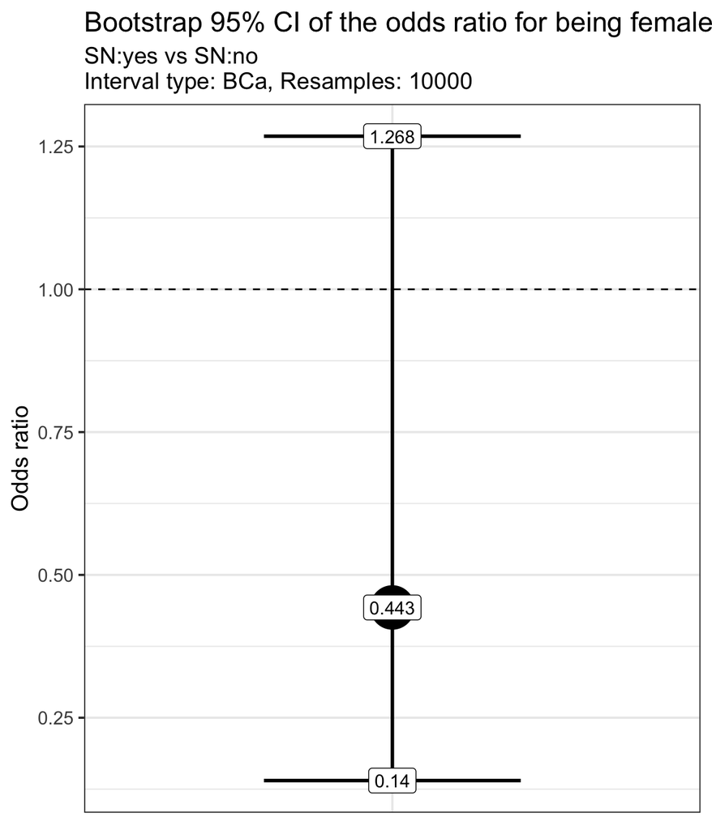

```r
ggplot(data = boot_sex) +
    geom_hline(yintercept = 1,
               linetype = 2) +
    geom_point(aes(x = 'x',
                   y = Odds.ratio),
               size = 12) +
    geom_errorbar(aes(x = 'x',
                      ymin = Bca.lower,
                      ymax = Bca.upper),
                  width = 0.5,
                  size = 1) +
    geom_label(aes(x = 'x',
                   y = Bca.lower,
                   label = Bca.lower)) +
    geom_label(aes(x = 'x',
                   y = Odds.ratio,
                   label = Odds.ratio)) +
    geom_label(aes(x = 'x',
                   y = Bca.upper,
                   label = Bca.upper)) +
    labs(title = 'Bootstrap 95% CI of the odds ratio for being female',
         subtitle = "SN:yes vs SN:no\nInterval type: BCa, Resamples: 10000",
         y = 'Odds ratio') +
    theme(axis.ticks.x = element_blank(),
          axis.text.x = element_blank(),
          axis.title.x = element_blank())
```

## CD4 T-cell count

```r
# Tabular summary
data %>%
    select(CD4_cell.ul, sn_present) %>%
    group_by(sn_present) %>%
    skim()
```

```
## Skim summary statistics
##  n obs: 83
##  n variables: 2
##  group variables: sn_present
##
## ── Variable type:numeric ───────────────────────────────────────────────────────────────
##  sn_present    variable missing complete  n   mean     sd p0   p25   p50
##         yes CD4_cell.ul       0       20 20 223.55 176.37  4  71.5 200.5
##          no CD4_cell.ul       0       63 63 249.78 183.25  1 127   235
##     p75 p100     hist
##  308.25  673 ▇▃▃▃▂▂▁▁
##  317     867 ▅▇▇▃▁▁▁▁
```

```r
# 95% bootstrap confidence interval of the median CD4 T-cell count by SN status
## Method = BCa, Resamples = 10000
set.seed(1234)
groupwiseMedian(CD4_cell.ul ~ sn_present,
                data = data,
                R = 10000,
                boot = TRUE,
                bca = TRUE)[c(1:3, 5, 6, 7)]
```

```
##   sn_present  n Median Conf.level Bca.lower Bca.upper
## 1        yes 20    200       0.95        77       290
## 2         no 63    235       0.95       149       286
```

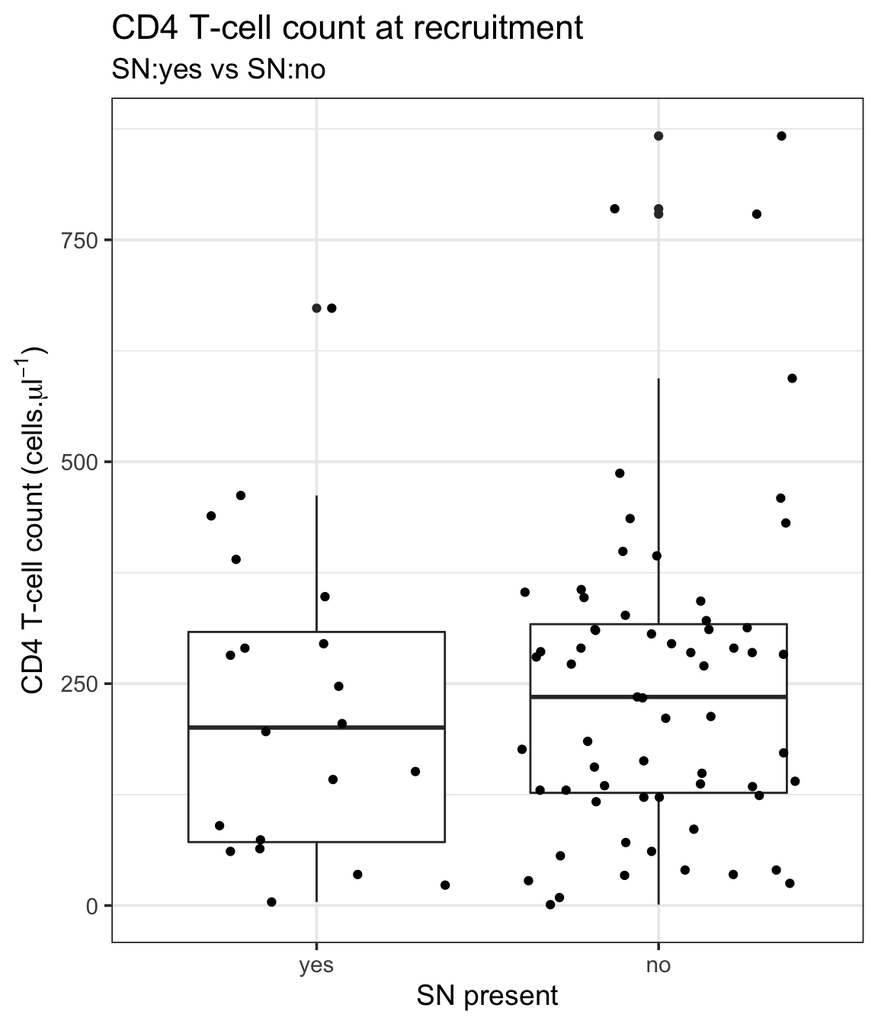

```r
# Plot
data %>%
    ggplot(data = .) +
    aes(y = CD4_cell.ul,
        x = sn_present) +
    geom_boxplot() +
    geom_jitter(height = 0) +
    labs(title = 'CD4 T-cell count at recruitment',
         subtitle = "SN:yes vs SN:no",
         y = expression(paste('CD4 T-cell count (cells.', mu, l^-1, ')')),
         x = 'SN present')
```

```r
# Bootstrap 95% CI for the difference in median CD4 T-cell count
## Resample: 10000
set.seed(1234)
boot_cd4 <- boot.ci(boot(data = data,
                         statistic = boot_deltaMedian,
                         data_column = 'CD4_cell.ul',
                         grouping_column = 'sn_present',
                         R = 10000,
                         stype = 'i'),
                    type = 'bca') %>%
    data_frame(n = nrow(filter(data, !is.na(CD4_cell.ul))),
               Median.difference = round(.$t0, 3),
               Conf.level = 0.95,
               Bca.lower = round(.$bca[[4]], 3),
               Bca.upper = round(.$bca[[5]], 3),
               Includes.zero = ifelse(Bca.lower <= 0 & Bca.upper >= 0,
                                      yes = 'yes',
                                      no = 'no')) %>%
    .[1, -1] %>%
    as.data.frame(); boot_cd4
```

```
##    n Median.difference Conf.level Bca.lower Bca.upper Includes.zero
## 1 83             -34.5       0.95      -180       106           yes
```

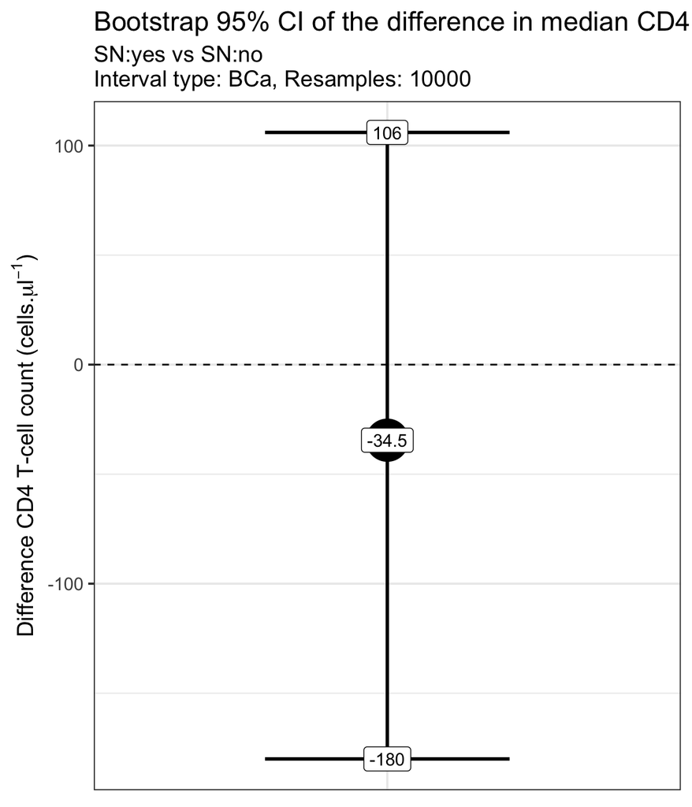

```r
ggplot(data = boot_cd4) +
     geom_hline(yintercept = 0,
               linetype = 2) +
    geom_point(aes(x = 'x',
                   y = Median.difference),
               size = 12) +
    geom_errorbar(aes(x = 'x',
                      ymin = Bca.lower,
                      ymax = Bca.upper),
                  width = 0.5,
                  size = 1) +
    geom_label(aes(x = 'x',
                   y = Bca.lower,
                   label = Bca.lower)) +
    geom_label(aes(x = 'x',
                   y = Median.difference,
                   label = Median.difference)) +
    geom_label(aes(x = 'x',
                   y = Bca.upper,
                   label = Bca.upper)) +
   labs(title = 'Bootstrap 95% CI of the difference in median CD4 T-cell count',
         subtitle = "SN:yes vs SN:no\nInterval type: BCa, Resamples: 10000",
         y = expression(paste('Difference CD4 T-cell count (cells.', mu, l^-1, ')'))) +
    theme(axis.ticks.x = element_blank(),
          axis.text.x = element_blank(),
          axis.title.x = element_blank())
```

## Viral load

```r
# Tabular summary
data %>%
    select(viral_load_copies.ml, sn_present) %>%
    group_by(sn_present) %>%
    skim()
```

```
## Skim summary statistics
##  n obs: 83
##  n variables: 2
##  group variables: sn_present
##
## ── Variable type:numeric ───────────────────────────────────────────────────────────────
##  sn_present             variable missing complete  n mean   sd   p0  p25
##         yes viral_load_copies.ml       1       19 20 3.59 1.59 1.83 2.22
##          no viral_load_copies.ml       5       58 63 3.37 1.28 1.7  2.25
##   p50  p75 p100     hist
##  3    4.73 6.45 ▇▃▂▃▁▁▂▃
##  3.13 4.22 6.51 ▇▅▆▂▅▂▁▂
```

```r
# 95% bootstrap confidence interval of the median viral load by SN status
## Method = BCa, Resamples = 10000
set.seed(1234)
groupwiseMedian(viral_load_copies.ml ~ sn_present,
                data = data[!is.na(data$viral_load_copies.ml), ], # Remove <NA>
                R = 10000,
                boot = TRUE,
                bca = TRUE)[c(1:3, 5, 6, 7)]
```

```
##   sn_present  n Median Conf.level Bca.lower Bca.upper
## 1        yes 19   3.00       0.95      2.08      4.08
## 2         no 58   3.13       0.95      2.78      3.60
```

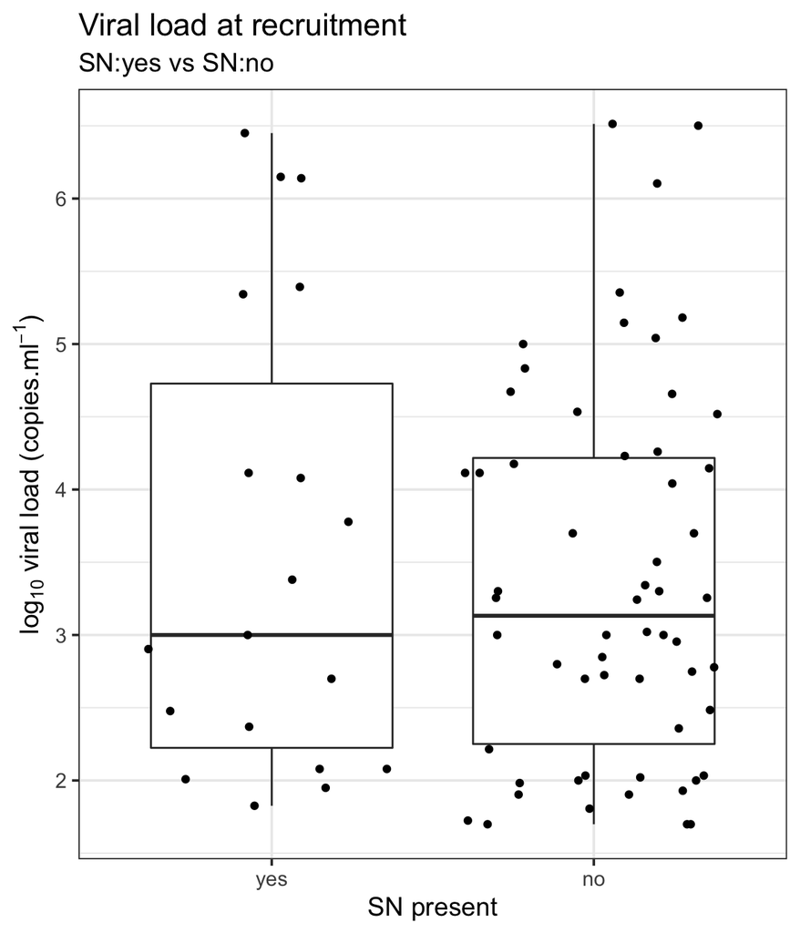

```r
# Plot
data %>%
    filter(!is.na(viral_load_copies.ml)) %>%
    ggplot(data = .) +
    aes(y = viral_load_copies.ml,
        x = sn_present) +
    geom_boxplot() +
    geom_jitter(height = 0) +
    labs(title = 'Viral load at recruitment',
         subtitle = 'SN:yes vs SN:no',
         x = 'SN present',
         y = expression(paste('log' [10], ' viral load (copies.ml' ^-1, ')')))
```

```r
# Bootstrap 95% CI for the difference in median viral load
## Resample: 10000
set.seed(1234)
boot_vl <- boot.ci(boot(data = data,
                        statistic = boot_deltaMedian,
                        data_column = 'viral_load_copies.ml',
                        grouping_column = 'sn_present',
                        R = 10000,
                        stype = 'i'),
                   type = 'bca') %>%
    data_frame(n = nrow(filter(data, !is.na(viral_load_copies.ml))),
               Median.difference = round(.$t0, 3),
               Conf.level = 0.95,
               Bca.lower = round(.$bca[[4]], 3),
               Bca.upper = round(.$bca[[5]], 3),
               Includes.zero = ifelse(Bca.lower <= 0 & Bca.upper >= 0,
                                      yes = 'yes',
                                      no = 'no')) %>%
    .[1, -1] %>%
    as.data.frame(); boot_vl
```

```
##    n Median.difference Conf.level Bca.lower Bca.upper Includes.zero
## 1 77            -0.132       0.95     -1.14     1.079           yes
```

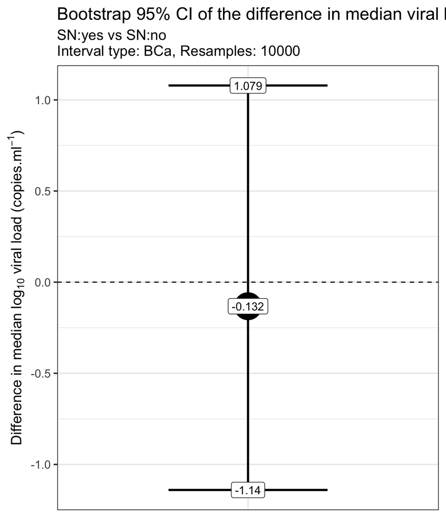

```r
ggplot(data = boot_vl) +
    geom_hline(yintercept = 0,
               linetype = 2) +
    geom_point(aes(x = 'x',
                   y = Median.difference),
               size = 12) +
    geom_errorbar(aes(x = 'x',
                      ymin = Bca.lower,
                      ymax = Bca.upper),
                  width = 0.5,
                  size = 1) +
    geom_label(aes(x = 'x',
                   y = Bca.lower,
                   label = Bca.lower)) +
    geom_label(aes(x = 'x',
                   y = Median.difference,
                   label = Median.difference)) +
    geom_label(aes(x = 'x',
                   y = Bca.upper,
                   label = Bca.upper)) +
    labs(title = 'Bootstrap 95% CI of the difference in median viral load',
         subtitle = "SN:yes vs SN:no\nInterval type: BCa, Resamples: 10000",
         y = expression(paste('Difference in median log' [10], ' viral load (copies.ml' ^-1, ')'))) +
    theme(axis.ticks.x = element_blank(),
          axis.text.x = element_blank(),
          axis.title.x = element_blank())
```

## Alcohol

```r
# Tabular summary
data %>%
    select(alcohol_units.week, sn_present) %>%
    mutate(drinks_alcohol = case_when(
        alcohol_units.week >= 1 ~ 'Yes',
        alcohol_units.week == 0 ~ 'No'
    )) %>%
    mutate(drinks_alcohol = factor(drinks_alcohol)) %>%
    group_by(sn_present, drinks_alcohol) %>%
    skim()
```

```
## Skim summary statistics
##  n obs: 83
##  n variables: 3
##  group variables: sn_present, drinks_alcohol
##
## ── Variable type:integer ───────────────────────────────────────────────────────────────
##  sn_present drinks_alcohol           variable missing complete  n mean
##         yes             No alcohol_units.week       0       18 18  0
##         yes            Yes alcohol_units.week       0        2  2  7.5
##          no             No alcohol_units.week       0       49 49  0
##          no            Yes alcohol_units.week       0       14 14 11
##    sd p0  p25 p50   p75 p100     hist
##  0     0 0    0    0       0 ▁▁▁▇▁▁▁▁
##  4.95  4 5.75 7.5  9.25   11 ▇▁▁▁▁▁▁▇
##  0     0 0    0    0       0 ▁▁▁▇▁▁▁▁
##  7.92  3 4.5  9   15      29 ▇▅▂▃▂▂▁▂
```

```r
# ALCOHOL DRINKERS ONLY
## 95% bootstrap confidence interval of the median alcohol consumption by SN status
### Method = BCa, Resamples = 10000
set.seed(1234)
groupwiseMedian(alcohol_units.week ~ sn_present,
                data = data[data$alcohol_units.week > 0, ], # Remove none drinkers
                R = 10000,
                boot = TRUE,
                bca = TRUE)[c(1:3, 5, 6, 7)]
```

```
##   sn_present  n Median Conf.level Bca.lower Bca.upper
## 1        yes  2    7.5       0.95       4.0       7.5
## 2         no 14    9.0       0.95       3.5      13.0
```

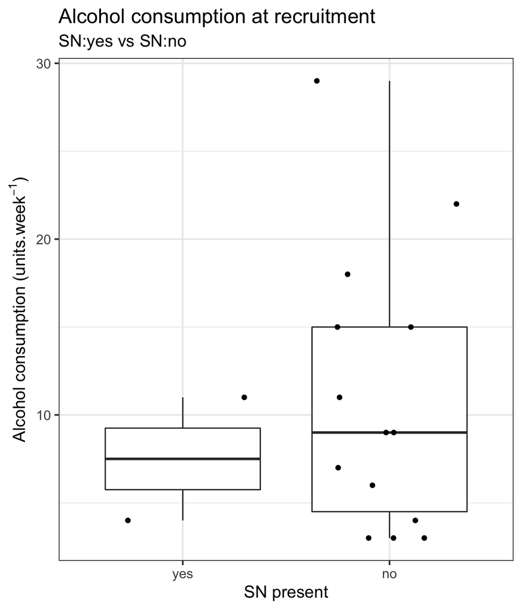

```r
# Plot
data %>%
    filter(alcohol_units.week > 0) %>%
    ggplot(data = .) +
    aes(x = sn_present,
        y = alcohol_units.week) +
    geom_boxplot() +
    geom_jitter(height = 0) +
    labs(title = 'Alcohol consumption at recruitment',
         subtitle = 'SN:yes vs SN:no',
         x = 'SN present',
         y = expression(paste('Alcohol consumption (units.week' ^-1, ')')))
```

```r
# With only two drinkers in the SN:yes group, we did not pursue additional exploration.
```

## TB

*Note: Treatment policy was to start some patients, irrespective of TB diagnosis, on TB treatment. Therefore current TB infection and treatment for TB analysed separately.*

### Currently infected with TB

```r
# Tabular summary
data %>%
    select(TB_current, sn_present) %>%
    group_by(sn_present) %>%
    skim()
```

```
## Skim summary statistics
##  n obs: 83
##  n variables: 2
##  group variables: sn_present
##
## ── Variable type:factor ────────────────────────────────────────────────────────────────
##  sn_present   variable missing complete  n n_unique            top_counts
##         yes TB_current       0       20 20        2 no: 11, yes: 9, NA: 0
##          no TB_current       0       63 63        2 no: 56, yes: 7, NA: 0
##  ordered
##    FALSE
##    FALSE
```

```r
# 95% bootstrap confidence interval of the proportion with current TB by SN status
## Method = BCa, Resamples = 10000
### SN:yes
set.seed(1234)
sn_yes <- boot.ci(boot(data = data[data$sn_present == 'yes', ],
                       statistic = function(d, i){
                           mean(d[i, 'TB_current'] == 'yes')},
                       R = 10000,
                       stype = 'i'),
                  type = 'bca') %>%
    data_frame(sn_present = 'yes',
               n = nrow(filter(data, !is.na(TB_current) &
                                   sn_present == 'yes')),
               Proportion = round(.$t0, 3),
               Conf.level = 0.95,
               Bca.lower = round(.$bca[[4]], 3),
               Bca.upper = round(.$bca[[5]], 3)) %>%
    .[1, -1] %>%
    as.data.frame()

### SN:no
set.seed(1234)
sn_no <- boot.ci(boot(data = data[data$sn_present == 'no', ],
                      statistic = function(d, i){
                          mean(d[i, 'TB_current'] == 'yes')},
                      R = 10000,
                      stype = 'i'),
                 type = 'bca') %>%
    data_frame(sn_present = 'no',
               n = nrow(filter(data, !is.na(TB_current) &
                                   sn_present == 'no')),
               Proportion = round(.$t0, 3),
               Conf.level = 0.95,
               Bca.lower = round(.$bca[[4]], 3),
               Bca.upper = round(.$bca[[5]], 3)) %>%
    .[1, -1] %>%
    as.data.frame()

### Put sn and sn_no together and print
sn_yes %>%
    bind_rows(sn_no)
```

```
##   sn_present  n Proportion Conf.level Bca.lower Bca.upper
## 1        yes 20      0.450       0.95     0.200      0.60
## 2         no 63      0.111       0.95     0.032      0.19
```

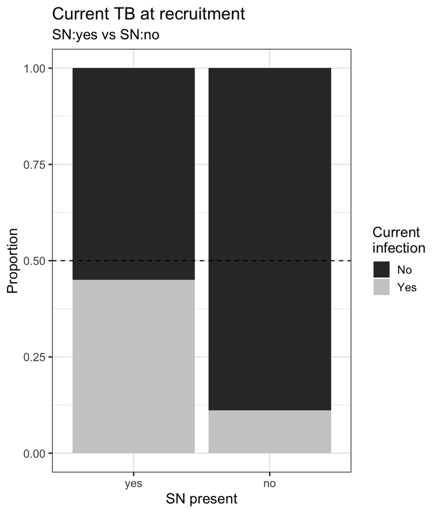

```r
# Plot
data %>%
    mutate(TB_current = str_to_title(TB_current)) %>%
    ggplot(data = .) +
    aes(x = sn_present,
        fill = TB_current) +
    geom_bar(position = 'fill') +
    geom_hline(yintercept = 0.5,
               linetype = 2) +
    labs(title = 'Current TB at recruitment',
         subtitle = 'SN:yes vs SN:no',
         x = 'SN present',
         y = 'Proportion') +
    scale_fill_grey(name = 'Current\ninfection')
```

```r
# Bootstrap 95% CI for the odds ratio of current TB in SN:yes vs SN:no
## Resample: 10000
set.seed(1234)
boot_tb <- boot.ci(boot(data = data,
                        statistic = boot_OR,
                        data_column = 'TB_current',
                        grouping_column = 'sn_present',
                        R = 10000,
                        stype = 'i'),
                   type = 'bca') %>%
    data_frame(n = nrow(filter(data, !is.na(TB_current))),
               Odds.ratio = round(.$t0, 3),
               Conf.level = 0.95,
               Bca.lower = round(.$bca[[4]], 3),
               Bca.upper = round(.$bca[[5]], 3),
               Includes.zero = ifelse(Bca.lower <= 1 & Bca.upper >= 1,
                                      yes = 'yes',
                                      no = 'no')) %>%
    .[1, -1] %>%
    as.data.frame(); boot_tb
```

```
##    n Odds.ratio Conf.level Bca.lower Bca.upper Includes.zero
## 1 83      0.157       0.95     0.042     0.553            no
```

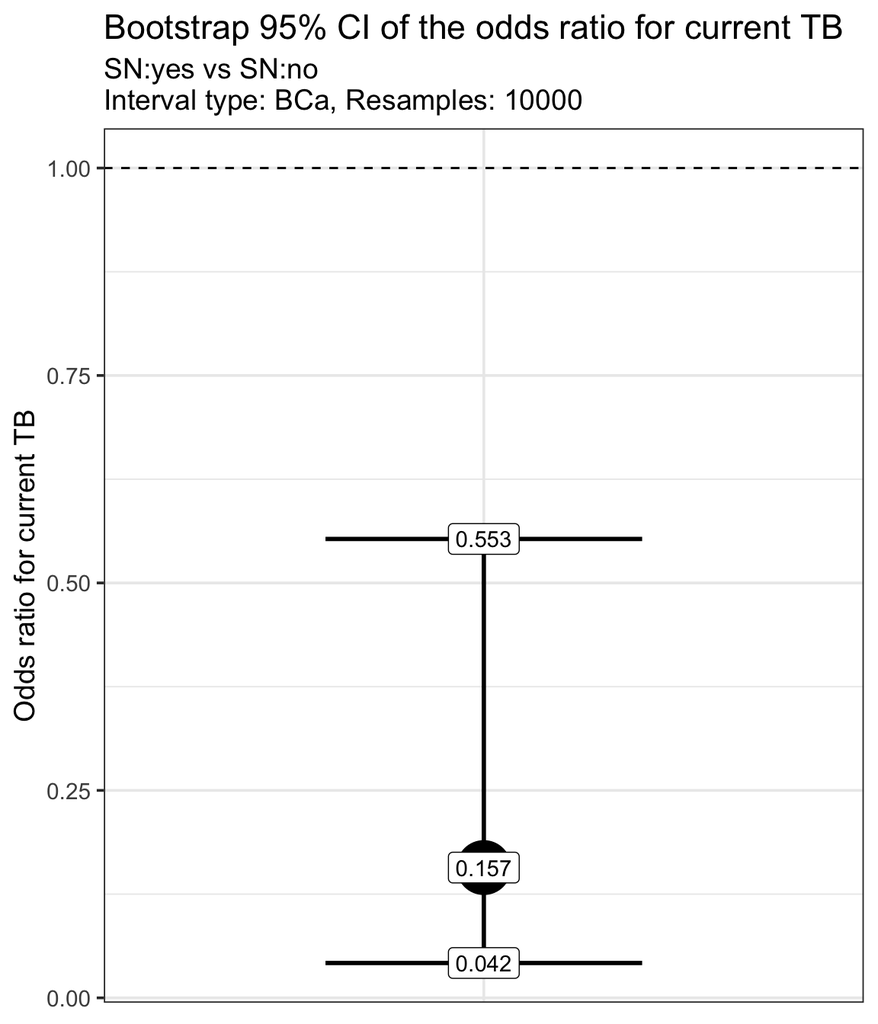

```r
ggplot(data = boot_tb) +
    geom_hline(yintercept = 1,
               linetype = 2) +
    geom_point(aes(x = 'x',
                   y = Odds.ratio),
               size = 12) +
    geom_errorbar(aes(x = 'x',
                      ymin = Bca.lower,
                      ymax = Bca.upper),
                  width = 0.5,
                  size = 1) +
    geom_label(aes(x = 'x',
                   y = Bca.lower,
                   label = Bca.lower)) +
    geom_label(aes(x = 'x',
                   y = Odds.ratio,
                   label = Odds.ratio)) +
    geom_label(aes(x = 'x',
                   y = Bca.upper,
                   label = Bca.upper)) +
    labs(title = 'Bootstrap 95% CI of the odds ratio for current TB',
         subtitle = "SN:yes vs SN:no\nInterval type: BCa, Resamples: 10000",
         y = 'Odds ratio for current TB') +
    theme(axis.ticks.x = element_blank(),
          axis.text.x = element_blank(),
          axis.title.x = element_blank())
```

### Currently receiving TB treatment?

Treatment consisted of rifafour and pyridoxine (prophylaxis). Therefore only need to analyse rifafour data. Data coded as *‘No’* (not being treated), *‘Yes’* (being treated for active TB), and *‘Prophylaxis’* (being treated prophylactically for TB).

```r
# Double-check matching between rifafour and pyridoxine columns
unique(data$rifafour_treatment == data$pyridoxine_prophylaxis)
```

```
## [1] TRUE
```

```r
# Tabular summary
data %>%
    select(rifafour_treatment, pyridoxine_prophylaxis, sn_present) %>%
    group_by(pyridoxine_prophylaxis, sn_present) %>%
    skim()
```

```
## Skim summary statistics
##  n obs: 83
##  n variables: 3
##  group variables: pyridoxine_prophylaxis, sn_present
##
## ── Variable type:factor ────────────────────────────────────────────────────────────────
##  pyridoxine_prophylaxis sn_present           variable missing complete  n
##                      no        yes rifafour_treatment       0       12 12
##                      no         no rifafour_treatment       0       54 54
##                     yes        yes rifafour_treatment       0        8  8
##                     yes         no rifafour_treatment       0        7  7
##             prophylaxis         no rifafour_treatment       0        2  2
##  n_unique                    top_counts ordered
##         1 no: 12, yes: 0, pro: 0, NA: 0   FALSE
##         1 no: 54, yes: 0, pro: 0, NA: 0   FALSE
##         1  yes: 8, no: 0, pro: 0, NA: 0   FALSE
##         1  yes: 7, no: 0, pro: 0, NA: 0   FALSE
##         1  pro: 2, no: 0, yes: 0, NA: 0   FALSE
```

```r
# Proportion on prophylaxis treatment
## Too low to analyse separately
round(mean(data$rifafour_treatment == 'prophylaxis'), 3)
```

```
## [1] 0.024
```

```r
## ...so collapse 'yes' and 'prophylaxis'
data_tb <- data %>%
    mutate(rifafour_treatment = fct_collapse(rifafour_treatment,
                                             yes = c('yes', 'prophylaxis')))

# 95% bootstrap confidence interval of the proportion with current TB treatment by SN status
## Method = BCa, Resamples = 10000
### SN:yes
set.seed(1234)
sn_yes <- boot.ci(boot(data = data_tb[data_tb$sn_present == 'yes', ],
                       statistic = function(d, i){
                           mean(d[i, 'rifafour_treatment'] == 'yes')},
                       R = 10000,
                       stype = 'i'),
                  type = 'bca') %>%
    data_frame(sn_present = 'yes',
               n = nrow(filter(data_tb, !is.na(rifafour_treatment) &
                                   sn_present == 'yes')),
               Proportion = round(.$t0, 3),
               Conf.level = 0.95,
               Bca.lower = round(.$bca[[4]], 3),
               Bca.upper = round(.$bca[[5]], 3)) %>%
    .[1, -1] %>%
    as.data.frame()

### SN:no
set.seed(1234)
sn_no <- boot.ci(boot(data = data_tb[data_tb$sn_present == 'no', ],
                      statistic = function(d, i){
                          mean(d[i, 'rifafour_treatment'] == 'yes')},
                      R = 10000,
                      stype = 'i'),
                 type = 'bca') %>%
    data_frame(sn_present = 'no',
               n = nrow(filter(data_tb, !is.na(rifafour_treatment) &
                                   sn_present == 'no')),
               Proportion = round(.$t0, 3),
               Conf.level = 0.95,
               Bca.lower = round(.$bca[[4]], 3),
               Bca.upper = round(.$bca[[5]], 3)) %>%
    .[1, -1] %>%
    as.data.frame()

### Put sn and sn_no together and print
sn_yes %>%
    bind_rows(sn_no)
```

```
##   sn_present  n Proportion Conf.level Bca.lower Bca.upper
## 1        yes 20      0.400       0.95     0.150     0.550
## 2         no 63      0.143       0.95     0.063     0.222
```

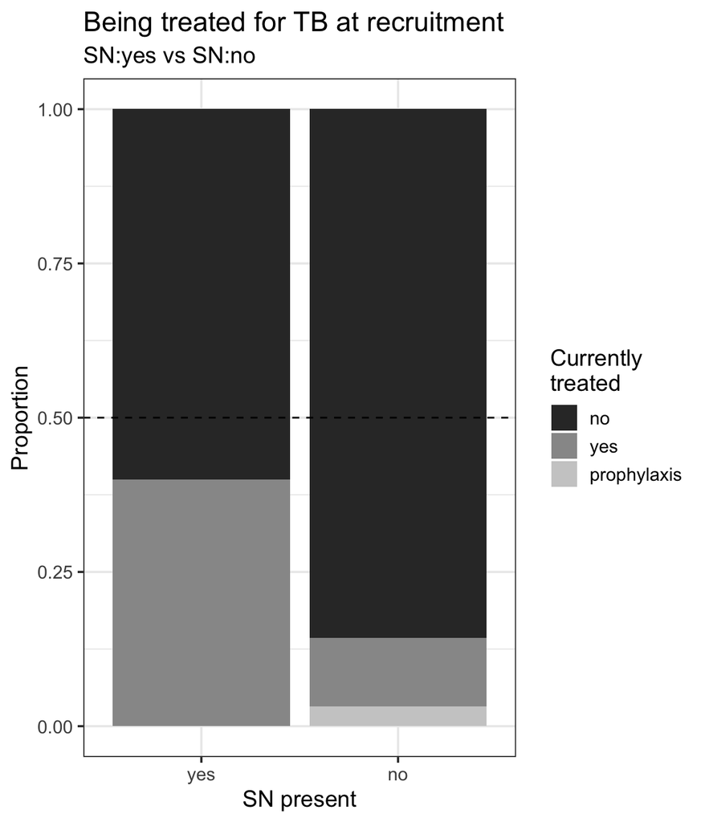

```r
# Plot
data %>%
    mutate(TB_current = str_to_title(rifafour_treatment)) %>%
    ggplot(data = .) +
    aes(x = sn_present,
        fill = rifafour_treatment) +
    geom_bar(position = 'fill') +
    geom_hline(yintercept = 0.5,
               linetype = 2) +
    labs(title = 'Being treated for TB at recruitment',
         subtitle = 'SN:yes vs SN:no',
         x = 'SN present',
         y = 'Proportion') +
    scale_fill_grey(name = 'Currently\ntreated')
```

```r
# Bootstrap 95% CI for the odds ratio of current TB treatment by SN status
## Resample: 10000
set.seed(1234)
boot_tb2 <- boot.ci(boot(data = data_tb,
                         statistic = boot_OR,
                         data_column = 'rifafour_treatment',
                         grouping_column = 'sn_present',
                         R = 10000,
                         stype = 'i'),
                    type = 'bca') %>%
    data_frame(n = nrow(filter(data_tb, !is.na(rifafour_treatment))),
               Odds.ratio = round(.$t0, 3),
               Conf.level = 0.95,
               Bca.lower = round(.$bca[[4]], 3),
               Bca.upper = round(.$bca[[5]], 3),
               Includes.zero = ifelse(Bca.lower <= 1 & Bca.upper >= 1,
                                      yes = 'yes',
                                      no = 'no')) %>%
    .[1, -1] %>%
    as.data.frame(); boot_tb2
```

```
##    n Odds.ratio Conf.level Bca.lower Bca.upper Includes.zero
## 1 83      0.255       0.95     0.074     0.853            no
```

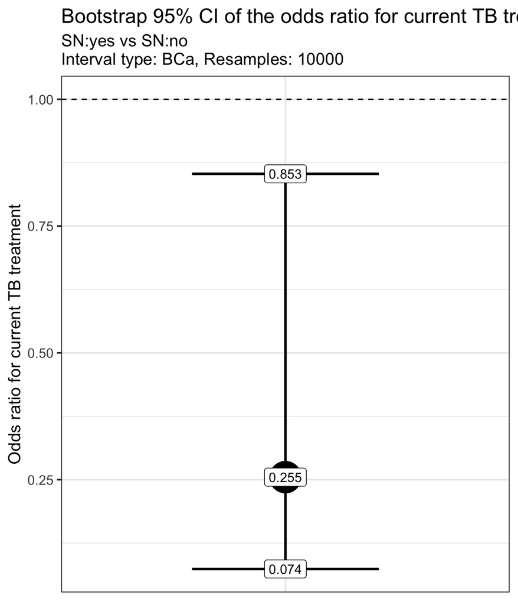

```r
ggplot(data = boot_tb2) +
    geom_hline(yintercept = 1,
               linetype = 2) +
    geom_point(aes(x = 'x',
                   y = Odds.ratio),
               size = 12) +
    geom_errorbar(aes(x = 'x',
                      ymin = Bca.lower,
                      ymax = Bca.upper),
                  width = 0.5,
                  size = 1) +
    geom_label(aes(x = 'x',
                   y = Bca.lower,
                   label = Bca.lower)) +
    geom_label(aes(x = 'x',
                   y = Odds.ratio,
                   label = Odds.ratio)) +
    geom_label(aes(x = 'x',
                   y = Bca.upper,
                   label = Bca.upper)) +
    labs(title = 'Bootstrap 95% CI of the odds ratio for current TB treatment',
         subtitle = "SN:yes vs SN:no\nInterval type: BCa, Resamples: 10000",
         y = 'Odds ratio for current TB treatment') +
    theme(axis.ticks.x = element_blank(),
          axis.text.x = element_blank(),
          axis.title.x = element_blank())
```